# Project 1: Wrangling, Exploration, Visualization

SDS322E

## Data Wrangling, Exploration, Visualization

### Sapna Bhakta

#### Introduction

First I found two datasets with data on makeup brands and products from Sephora and Ulta. This contained links and a description of the products. Second I gathered a dataset called allShades that had more specific product information. From these columns, I focused on analyzing the hue, saturation, and lightness of each product. All three datasets were found through rfordatascience on github where I downloaded csv files and read them through. Through my visualizations I decide to analyze some common drugstore-brand vs. high-end brands in order too see the variation in their product makeups. Analyzing this data interested me because some brands are known for having controversial shade selections and not catering to a variety of skin colors. I am also interested in makeup and was curious to see the diversity of options for various brands.

```r
library(tidyverse)
library(knitr)
sephora <- read_csv("https://raw.githubusercontent.com/rfordatascience/tidytuesday/master/data/2021/2021-03-30/sephora.csv")
ulta <- read_csv("https://raw.githubusercontent.com/rfordatascience/tidytuesday/master/data/2021/2021-03-30/ulta.csv")
allShades <- read_csv("https://raw.githubusercontent.com/rfordatascience/tidytuesday/master/data/2021/2021-03-30/allShades.csv")
```

#### Tidying: Reshaping

```r
stores <- full_join(sephora, ulta) %>% select(brand, product,
    specific)
shades <- allShades %>% select(brand, product, specific, colorspace,
    hue, sat, lightness)
```

I used one re-shaping tool in the wrangling section since the table was already tidy.

#### Joining/Merging

```r
nrow(stores)
```

```
## [1] 8375
```

```r
nrow(shades)
```

```
## [1] 6816
```

```r
length(unique(stores$brand))
```

```
## [1] 113
```

```r
length(unique(shades$brand))
```

```
## [1] 107
```

```r
missing <- anti_join(stores, shades, by = "brand")
unique(missing$brand)
```

```
## [1] "IT Cosmetics"      "Urban Decay"       "tarte"
## [4] "Hourglass"         "CLINIQUE"          "Sephora Favorites"
```

```r
inner_data <- inner_join(stores, shades)
length(unique(inner_data$brand))
```

```
## [1] 107
```

The Sephora and Ulta datasets which once joined are fully joined in order to maintain all rows was labeled stores. This dataset has 113 unique brands while the allShades dataset has 107 unique brands. I decided to do an inner join to keep only the brands that are present in both. The 6 brands that did not overlap are listed above. The inner_data dataset is 53133 observations which is significantly larger than the original datasets of 8375 and 6816 observations.

#### Wrangling

```r
inner_data %>% select(hue, sat, lightness) %>% summary() %>%
    kable()
```

|  | hue | sat | lightness |
| --- | --- | --- | --- |
|  | Min. : 0.00 | Min. :0.0000 | Min. :0.1549 |
|  | 1st Qu.: 22.00 | 1st Qu.:0.4074 | 1st Qu.:0.4922 |
|  | Median : 25.38 | Median :0.5043 | Median :0.6490 |
|  | Mean : 24.93 | Mean :0.5191 | Mean :0.6226 |
|  | 3rd Qu.: 28.50 | 3rd Qu.:0.6170 | 3rd Qu.:0.7529 |
|  | Max. :230.40 | Max. :1.0000 | Max. :0.9961 |

```r
inner_dataset <- inner_data %>% mutate(`hue/sat` = hue/sat, `hue/lightness` = hue/lightness,
    `sat/lightness` = sat/lightness)

dataset <- inner_data %>% group_by(brand, product) %>% summarize(mean_hue = mean(hue),
    mean_sat = mean(sat), mean_lightness = mean(lightness), sd_hue = sd(hue),
    sd_sat = sd(sat), sd_lightness = sd(lightness)) %>% mutate(`hue/sat` = mean_hue/mean_sat,
    `hue/lightness` = mean_hue/mean_lightness, `sat/lightness` = mean_sat/mean_lightness)
dataset <- dataset %>% mutate(brand = str_replace(brand, "FENTY BEAUTY by Rihanna",
    "FENTY"))

summary(dataset)
```

```
##     brand             product             mean_hue        mean_sat
##  Length:313         Length:313         Min.   : 2.00   Min.   :0.0200
##  Class :character   Class :character   1st Qu.:22.75   1st Qu.:0.4557
##  Mode  :character   Mode  :character   Median :24.57   Median :0.5171
##                                        Mean   :24.72   Mean   :0.5189
##                                        3rd Qu.:26.89   3rd Qu.:0.5860
##                                        Max.   :72.72   Max.   :0.8535
##
##  mean_lightness       sd_hue           sd_sat          sd_lightness
##  Min.   :0.2275   Min.   : 0.000   Min.   :0.008423   Min.   :0.002148
##  1st Qu.:0.5980   1st Qu.: 2.913   1st Qu.:0.080623   1st Qu.:0.102585
##  Median :0.6453   Median : 3.846   Median :0.115093   Median :0.135839
##  Mean   :0.6430   Mean   : 4.349   Mean   :0.117185   Mean   :0.132261
##  3rd Qu.:0.6925   3rd Qu.: 5.028   3rd Qu.:0.151615   3rd Qu.:0.161176
##  Max.   :0.9900   Max.   :95.012   Max.   :0.335547   Max.   :0.354940
##                   NA's   :7        NA's   :7          NA's   :7
##     hue/sat       hue/lightness    sat/lightness
##  Min.   : 26.34   Min.   :  2.02   Min.   :0.0202
##  1st Qu.: 41.40   1st Qu.: 34.46   1st Qu.:0.7203
##  Median : 47.23   Median : 38.79   Median :0.8143
##  Mean   : 50.26   Mean   : 39.30   Mean   :0.8197
##  3rd Qu.: 55.15   3rd Qu.: 42.91   3rd Qu.:0.9096
##  Max.   :376.31   Max.   :116.72   Max.   :3.0321
##
```

Here, I have created a inner_dataset that creates three new ratio variables. Then, a dataset is created that groups by brand and product so that stats are created for each product in their own line.

```r
library(knitr)
stores %>% summarize_all(function(x) sum(is.na(x))) %>% kable()
```

| brand | product | specific |
| --- | --- | --- |
| 0 | 0 | 2275 |

```r
shades %>% summarize_all(function(x) sum(is.na(x))) %>% kable()
```

| brand | product | specific | colorspace | hue | sat | lightness |
| --- | --- | --- | --- | --- | --- | --- |
| 0 | 0 | 1911 | 0 | 0 | 0 | 0 |

```r
inner_data %>% summarize_all(function(x) sum(is.na(x))) %>% kable()
```

| brand | product | specific | colorspace | hue | sat | lightness |
| --- | --- | --- | --- | --- | --- | --- |
| 0 | 0 | 47007 | 0 | 0 | 0 | 0 |

From the above tables, we can see that missing values are only present in the specific column which is handy since we don’t use it any graphs or new columns.

```r
table3 <- dataset %>% select(brand, product, contains("/")) %>%
    arrange(desc(`hue/sat`)) %>% head(3) %>% kable()
table3
```

| brand | product | hue/sat | hue/lightness | sat/lightness |
| --- | --- | --- | --- | --- |
| Clinique | Almost Powder Makeup | 376.3066 | 42.06186 | 0.1117755 |
| L.A. Girl | Pro Matte Mixing Pigment | 137.3309 | 116.72050 | 0.8499217 |
| Clinique | Superbalanced Makeup | 112.8123 | 15.79772 | 0.1400355 |

```r
table4 <- dataset %>% select(brand, product, contains("/")) %>%
    arrange(desc(`hue/lightness`)) %>% head(3) %>% kable()
table4
```

| brand | product | hue/sat | hue/lightness | sat/lightness |
| --- | --- | --- | --- | --- |
| L.A. Girl | Pro Matte Mixing Pigment | 137.33089 | 116.7205 | 0.8499217 |
| Marc Jacobs Beauty | Shameless Youthful-Look 24H Foundation SPF 25 | 34.80000 | 105.5172 | 3.0321046 |
| Physicians Formula | The Healthy Foundation SPF 20 | 46.03388 | 79.8404 | 1.7343837 |

```r
table5 <- dataset %>% select(brand, product, contains("/")) %>%
    arrange(desc(`sat/lightness`)) %>% head(3) %>% kable()
table5
```

| brand | product | hue/sat | hue/lightness | sat/lightness |
| --- | --- | --- | --- | --- |
| Marc Jacobs Beauty | Shameless Youthful-Look 24H Foundation SPF 25 | 34.80000 | 105.51724 | 3.032105 |
| Physicians Formula | The Healthy Foundation SPF 20 | 46.03388 | 79.84040 | 1.734384 |
| Marc Jacobs Beauty | Re(marc)able Full Cover Foundation Concentrate | 40.63508 | 54.80653 | 1.348749 |

Here, I have created three tables with each in descending order of ratio value. This was just some exploratory analysis to see that the Clinique - Almost Powder Makeup has the highest hue/sat ratio, L.A. Girl - Pro Matte Mixing Pigment has the highest hue/lightness ratio, and Marc Jacobs - Shameless Youthful has the highest sat/lightness ratio.

```r
dataset %>% select(brand, product) %>% summarize(count = n()) %>%
    arrange(desc(count)) %>% head(10) %>% pivot_wider(names_from = "brand",
    values_from = "count")
```

```
## # A tibble: 1 x 10
##   bareMinerals `It Cosmetics` Clinique `SEPHORA COLLEC…  Dior Tarte
##          <int>          <int>    <int>            <int> <int> <int>
## 1           15             10        9                9     8     8
## # … with 4 more variables: `Armani Beauty` <int>, `L'Oréal` <int>, `Laura
## #   Mercier` <int>, `Bobbi Brown` <int>
```

From the above table, I have counted the categorical data to see how many products of each brand there are. Since the full table would have 107 columns, I kept it to only 10 and we can see the top 10 brands that we have the most variety of product information on.

```r
grouped <- dataset %>% group_by(brand) %>% summarize(mean_hue = mean(mean_hue),
    mean_sat = mean(mean_sat), mean_lightness = mean(mean_lightness))
```

Since there are so many products for each brand totaled up, I created another dataset grouped off of brand. This creates a line for each brand that has the averages of the means.

```r
table3 <- grouped %>% arrange(desc(mean_hue)) %>% head(3) %>%
    kable()
table3
```

| brand | mean_hue | mean_sat | mean_lightness |
| --- | --- | --- | --- |
| L.A. Girl | 41.87587 | 0.4874829 | 0.5773602 |
| The Ordinary | 33.67485 | 0.5656272 | 0.7491622 |
| Burt’s Bees | 32.29876 | 0.4278916 | 0.6076797 |

```r
table4 <- grouped %>% arrange(desc(mean_sat)) %>% head(3) %>%
    kable()
table4
```

| brand | mean_hue | mean_sat | mean_lightness |
| --- | --- | --- | --- |
| Winky Lux | 22.33308 | 0.8285884 | 0.7666667 |
| J.Cat Beauty | 24.06444 | 0.7167447 | 0.6786859 |
| Hynt Beauty | 30.79522 | 0.6811903 | 0.7047619 |

```r
table5 <- grouped %>% arrange(desc(mean_lightness)) %>% head(3) %>%
    kable()
table5
```

| brand | mean_hue | mean_sat | mean_lightness |
| --- | --- | --- | --- |
| Erborian | 2.00000 | 0.0200000 | 0.9900000 |
| Winky Lux | 22.33308 | 0.8285884 | 0.7666667 |
| W3LL PEOPLE | 21.52971 | 0.5605952 | 0.7665850 |

From the above tables, we can see that L.A. Girl has the highest mean hue, Winky Lux has the highest mean saturation, and Eborian has the highest mean lightness.

#### Visualizing

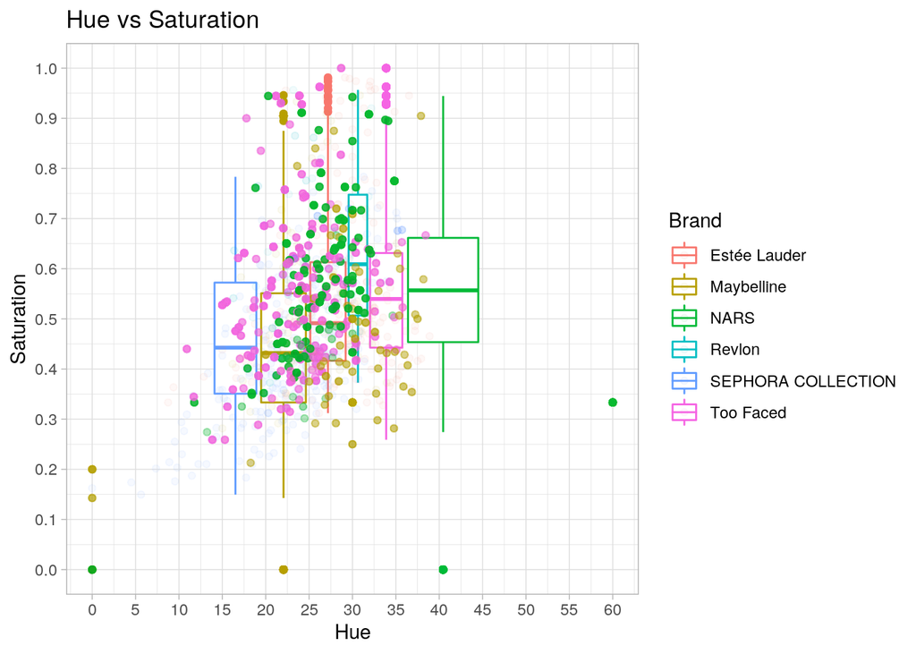

```r
subset1 <- inner_dataset %>% filter(brand == "NARS" | brand ==
    "Estée Lauder" | brand == "Too Faced" | brand == "SEPHORA COLLECTION" |
    brand == "Revlon" | brand == "Maybelline")

ggplot(subset1, aes(hue, sat, color = brand)) + geom_boxplot() +
    geom_jitter(alpha = 0.05) + labs(title = "Hue vs Saturation",
    x = "Hue", y = "Saturation", color = "Brand") + theme_light() +
    scale_x_continuous(breaks = seq(0, 60, 5)) + scale_y_continuous(breaks = seq(0,
    1, 0.1))
```

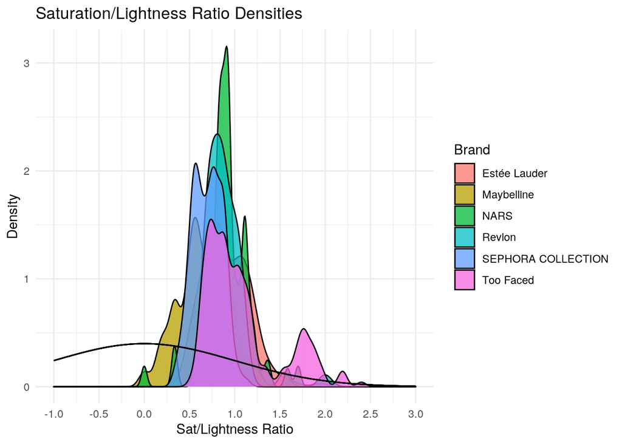

```r
ggplot(subset1, aes(x = `sat/lightness`, fill = brand)) + geom_density(alpha = 0.75) +
    geom_function(fun = dnorm) + labs(title = "Saturation/Lightness Ratio Densities",
    x = "Sat/Lightness Ratio", y = "Density", fill = "Brand") +
    theme_minimal() + scale_x_continuous(breaks = seq(-1, 3,
    0.5), limits = c(-1, 3))
```

From this graph, we can see that NARS has a spike in its density plot, whereas Maybelline’s plot seems to remain low. This means that there is a higher concentration of products for NARS with a ratio between 0 and 1.25. This is interesting because a high saturation/lightness ratio could be an indicator of the quality and pigmentation of products. On the contrary, Too Faced has a similar distribution to Maybelline but one is high-end and one is low-end. It can be difficult to interpret this graph, but the normal distribution line allows for some context as to how the distribution differs from the normal.

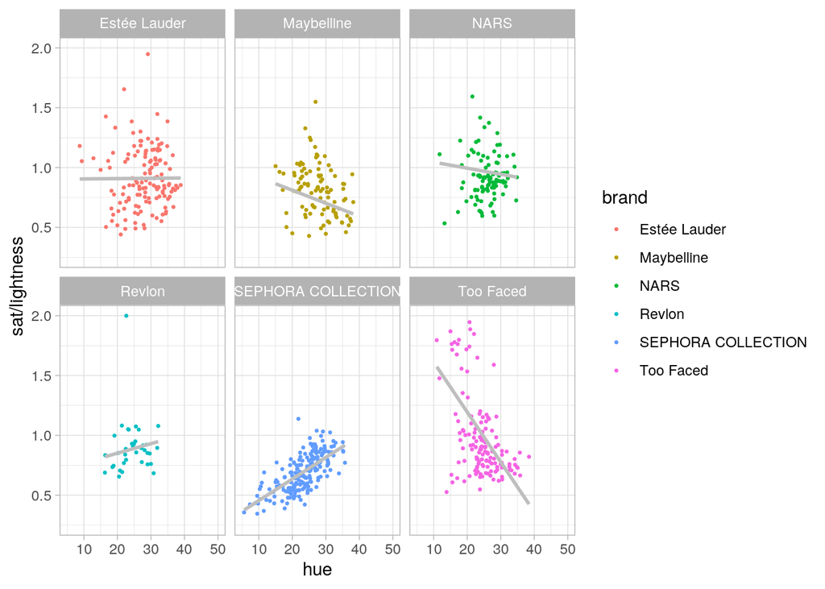

```r
ggplot(subset1, aes(x = hue, y = `sat/lightness`, color = brand)) +
    geom_point(stat = "summary", size = 0.5) + geom_smooth(method = "lm",
    level = 0, color = "gray") + facet_wrap(~brand) + theme_light() +
    scale_y_continuous(limits = c(0.25, 2)) + scale_x_continuous(limits = c(5,
    50))
```

For the final plot, I compared hue to the saturation/lightness ratio. The question was is hue increases (more colors) does the sat/lightness ratio increase or decrease? For Revlon and SEPHORA COLLECTION, there is a positive relationship. For Estee Lauder there is not a strong and evident correlation. For Maybelline, NARS, and Too Faced there seems to be a negative relationship. Specifically, if we look at Too Faced we can see that there is a cluster of low hue values that has a high sat/light ratio and a large cluster towards the bottom with high hue values and low sat/light ratio.

#### Concluding Remarks

I think the overall conclusion is that the data is messy, it is hard to zone in on all the values and ratios. It would require further analyzation of a wider range of brands in order to make any definitive conclusions.